# Lab 2 Answer Sheet

BIOS 10602 - Multiscale Modeling of Biological Systems

9/22/2021

## Part 1: Data frames

1.1 a  
Returns all the elements in the first column. Returns the element in the third row and first column. Returns the first through sixth elements of the third column. Returns the columns specified by the vector, in this case columns 1 and 4.

1.1 b  
Data frames have two dimensions, and thus you must specify both the row and column to grab an element. Otherwise, you may be returned a vector representing a column or row or a slice of a column or row.

1.2  
For each element in the 4th column, if the element is greater than 300, TRUE is put into a vector, otherwise FALSE is. This vector is then used to index yeastProt. For all elements in column 2, if the corresponding element in the TRUE/FALSE vector is TRUE, the element is added to a vector which is returned afterward.

1.3

```r
yeastProt$protName[yeastProt[, 4] > 300]
```

```
## [1] "enolase"
## [2] "glyceraldehyde-3-phosphate dehydrogenase"
## [3] "regulatory protein Gal4"
## [4] "DNA polymerase subunit alpha B"
## [5] "telomerase reverse transcriptase"
```

```r
yeastProt[yeastProt[, 4] > 300, "protName"]
```

```
## [1] "enolase"
## [2] "glyceraldehyde-3-phosphate dehydrogenase"
## [3] "regulatory protein Gal4"
## [4] "DNA polymerase subunit alpha B"
## [5] "telomerase reverse transcriptase"
```

1.4

```r
yeastProt[yeastProt[,4] > 100,]
```

```
##      id                                 protName abundance length
## 1  ENO2                                  enolase  24563.00    437
## 2  TDH3 glyceraldehyde-3-phosphate dehydrogenase  22369.00    332
## 4  GAL4                  regulatory protein Gal4     32.30    881
## 5 POL12           DNA polymerase subunit alpha B     13.70    705
## 6  EST2         telomerase reverse transcriptase      0.01    884
```

## Part 2: Matrices

2.1  
When byRow is set TRUE, the matrix is filled with vectors by row, thus the vector (1, 2) will be the first row. When byRow is FALSE, the columns are filled first, thus (1, 2) would end up as the first column.

2.2

```r
x <- matrix(nrow = 5, ncol = 5, data = 1:25)
mean(x)
```

```
## [1] 13
```

```r
sd(x)
```

```
## [1] 7.359801
```

```r
sum(x)
```

```
## [1] 325
```

R computes over all matrix elements

2.3

```r
mat <- matrix(nrow=4, ncol=4, data=1:16)
mat[1,] <- c(10, 20, 30, 40)
```

2.4

```r
mat <- matrix(nrow=4, ncol=5, data=1:20)
dim(mat)
```

```
## [1] 4 5
```

First is number of rows. Second is number of columns.

## Part 3: Getting familiar with the Golub data

3.1  
Single DNA strands are mixed with known single DNA strands. If compatible, they will bond to form a double strand, which will then give off light due to additional substances mixed with the genetic material. By doing many of such comparisons, the levels of gene expression can be studied via which sample give off what kind of light.

3.2  
Columns 1-27 represent ALL. 28-38 represent AML

3.3  
Gene names are Strings and can’t be included with the golub matrix since it must be all decimal numbers

3.4

```r
grep("cyclin D3", golub.gnames[,2], ignore.case=TRUE)
```

```
## [1] 1042
```

3.5

```r
mean(golub[1042, golub.cl == 0])
```

```
## [1] 1.893883
```

```r
mean(golub[1042, golub.cl == 1])
```

```
## [1] 0.6355909
```

ALL => 1.893883; AML => 0.6355909

3.6

```r
t.test(golub[1042,1:27],golub[1042,28:38])
```

```
##
##  Welch Two Sample t-test
##
## data:  golub[1042, 1:27] and golub[1042, 28:38]
## t = 6.3186, df = 16.118, p-value = 9.871e-06
## alternative hypothesis: true difference in means is not equal to 0
## 95 percent confidence interval:
##  0.8363826 1.6802008
## sample estimates:
## mean of x mean of y
## 1.8938826 0.6355909
```

p-value = 9.871e-06. We can reject the null hypothesis and conclude that the different values for the two groups did not just occur due to chance. Thus, we can be confident there was a significant differnece between levels of cyclin D3 gene expression between ALL and AML sufferers

3.7 a

```r
meanAML2 <- apply(golub[,28:38], 1, mean)
```

3.7 b

```r
meanALL2 <- apply(golub[,1:27], 1, mean)
meanABS <- abs(meanALL2 - meanAML2)
```

3.8

```r
o <- order(meanABS, decreasing=TRUE)
golub.gnames[o[1:8], 2]
```

```
## [1] "CST3 Cystatin C (amyloid angiopathy and cerebral hemorrhage)"
## [2] "INTERLEUKIN-8 PRECURSOR"
## [3] "Interleukin 8 (IL8) gene"
## [4] "DF D component of complement (adipsin)"
## [5] "MPO Myeloperoxidase"
## [6] "TCL1 gene (T cell leukemia) extracted from H.sapiens mRNA for Tcell leukemia/lymphoma 1"
## [7] "Azurocidin gene"
## [8] "CYSTATIN A"
```

3.9 a  
MPO Myeloperoxidase; TCL1 gene; CYSTATIN A

3.9 b  
Genes also correlate with class distinction

3.9 c  
Genes cast weighted votes, depending on expression level in the new sample and the correlation with the class distinction

3.10

```r
gol.fac <- factor(golub.cl, levels=c(0,1), labels = c("ALL","AML"))
```

Creates a mapping so that the levels vector elements correspond to the corresponding labels elements within the golub.cl vector

## Part 4: Making graphics in R

4.1

```r
plot(golub[1042,])
plot(golub[1042,], col = 28)
plot(golub[1042,], col = 28, pch = 2)
plot(golub[1042,], col = 28, type='l')
plot(golub[1042,], col = 28, type='l', lty=2)
plot(golub[1042,], col = 28, type='l', lty=2, xlab="patient index", ylab="normalized cyclin D3 expression")
plot(golub[1042,], col = 28, type='l', lty=2, xlab="patient index", ylab="normalized cyclin D3 expression", main="Example of plotting in R")
```

[output not shown]

col sets the color pch changes the shape of the points type changes the type of graph. In this case it becomes a line graph instead of a scatterplot lty changes the dotting of the graph xlab and ylab set xaxis and yaxis labels respectively main sets a title for the plot

4.2

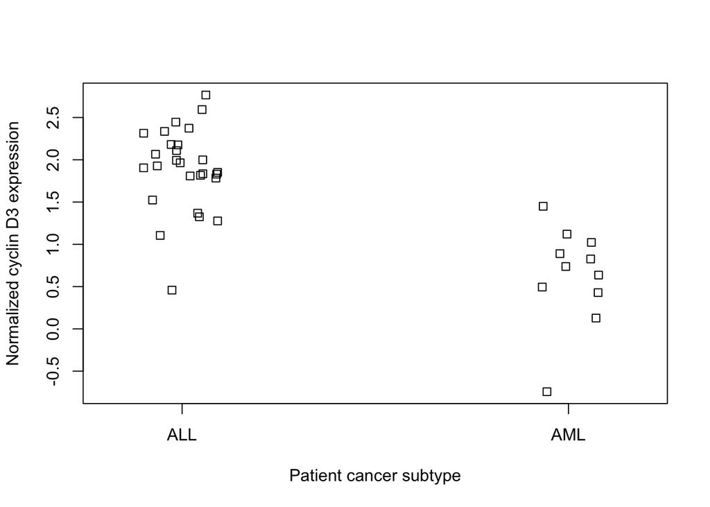

```r
stripchart(golub[1042,] ~ gol.fac, method="jitter", vertical=TRUE, xlab="Patient cancer subtype",  ylab="Normalized cyclin D3 expression")
```

4.3 a

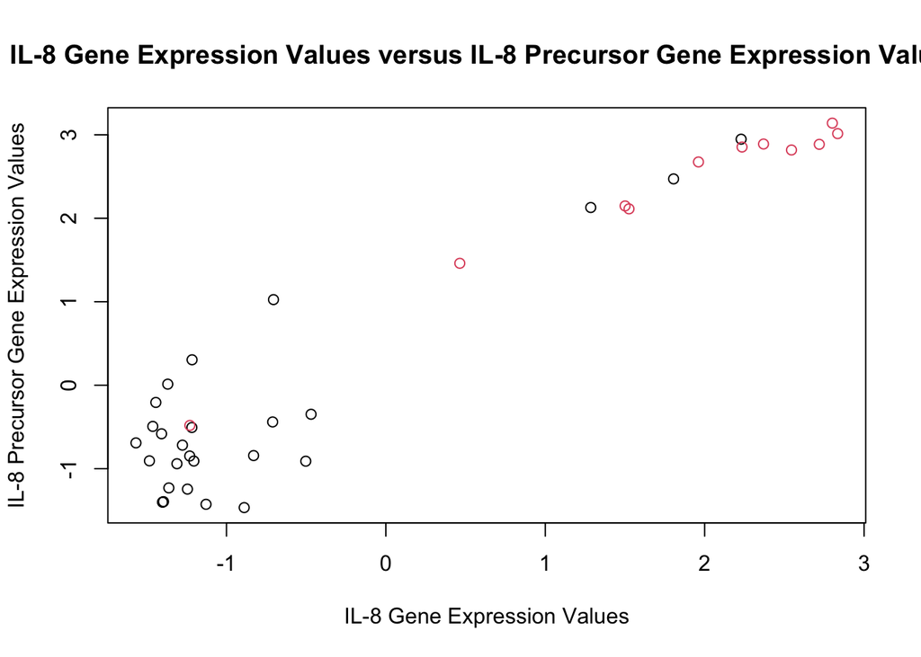

```r
plot(golub[2663,], golub[2664,], col=gol.fac, main="IL-8 Gene Expression Values versus IL-8 Precursor Gene Expression Values", xlab="IL-8 Gene Expression Values", ylab="IL-8 Precursor Gene Expression Values")
```

4.4

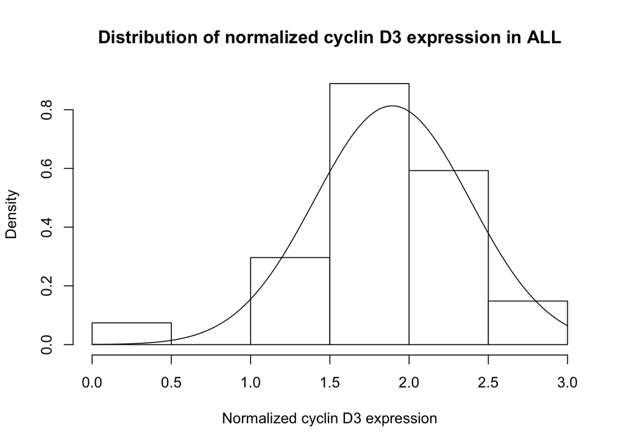

```r
hist(golub[1042,gol.fac == "ALL"], col="white", freq=FALSE, xlab="Normalized cyclin D3 expression", main="Distribution of normalized cyclin D3 expression in ALL")
curve(dnorm(x, mean = mean(golub[1042,gol.fac=="ALL"]), sd = sd(golub[1042,gol.fac=="ALL"])), add=TRUE)
```

4.5

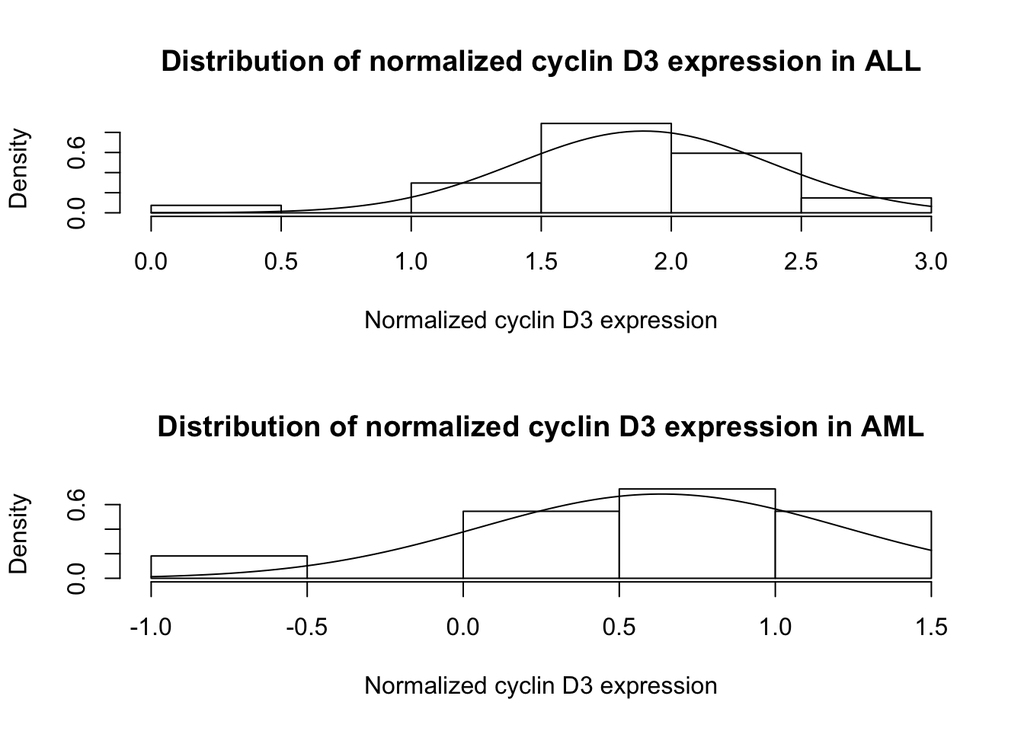

```r
par(mfrow=c(2, 1))
hist(golub[1042,gol.fac == "ALL"], col="white", freq=FALSE, xlab="Normalized cyclin D3 expression", main="Distribution of normalized cyclin D3 expression in ALL")
curve(dnorm(x, mean = mean(golub[1042,gol.fac=="ALL"]), sd = sd(golub[1042,gol.fac=="ALL"])), add=TRUE)
hist(golub[1042,gol.fac == "AML"], col="white", freq=FALSE, xlab="Normalized cyclin D3 expression", main="Distribution of normalized cyclin D3 expression in AML")
curve(dnorm(x, mean = mean(golub[1042,gol.fac=="AML"]), sd = sd(golub[1042,gol.fac=="AML"])), add=TRUE)
```

The gene in ALL appears slightly more normally distributed

4.6

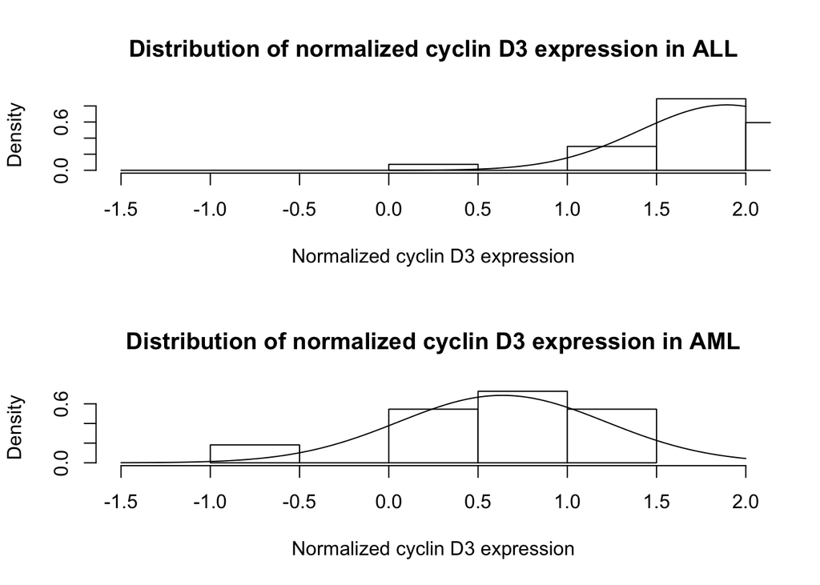

```r
par(mfrow=c(2, 1))
hist(golub[1042,gol.fac == "ALL"], col="white", freq=FALSE, xlab="Normalized cyclin D3 expression", main="Distribution of normalized cyclin D3 expression in ALL", xlim=range(-1.5, 2))
curve(dnorm(x, mean = mean(golub[1042,gol.fac=="ALL"]), sd = sd(golub[1042,gol.fac=="ALL"])), add=TRUE)
hist(golub[1042,gol.fac == "AML"], col="white", freq=FALSE, xlab="Normalized cyclin D3 expression", main="Distribution of normalized cyclin D3 expression in AML", xlim=range(-1.5, 2))
curve(dnorm(x, mean = mean(golub[1042,gol.fac=="AML"]), sd = sd(golub[1042,gol.fac=="AML"])), add=TRUE)
```

4.7 a

```r
grep("oncogene", golub.gnames[, 2], ignore.case = TRUE)
```

```
##  [1]  418  501  502  503  587  744  758  766  775  805  817  819  938 1067 1090
## [16] 1111 1211 1268 1542 1596 1615 1735 1747 1750 1788 1818 1820 1837 1839 2004
## [31] 2291 2302 2488 2516 2517 2539 2648 2661 2681 2692 2703 2714 2715 2892 2981
## [46] 2990 2993
```

4.7 b

```r
oncogenes <- grep("oncogene", golub.gnames[, 2], ignore.case = TRUE)
meanABS <- abs(apply(golub[oncogenes,28:38], 1, mean) - apply(golub[oncogenes,1:27], 1, mean))
o <- order(meanABS, decreasing=TRUE)
golub.gnames[oncogenes[o[1]], 2]
```

```
## [1] "GRO2 GRO2 oncogene"
```

GRO2 GRO2 oncogene

4.7 c

```r
meanABS <- abs(apply(golub[,1:27], 1, mean) - apply(golub[,28:38], 1, mean))
o <- order(meanABS, decreasing=TRUE)
"GRO2 GRO2 oncogene" %in% golub.gnames[o[1:30], 2]
```

```
## [1] TRUE
```

Yes

4.7 d  
Recall that in their study, Golub et al did not use a pure mean for predictive strength, rather a weighted score based on broader neighborhood analysis. It is possible that the GRO2 GRO2 oncogene was not a strong a predictor when using this method.

4.8 a

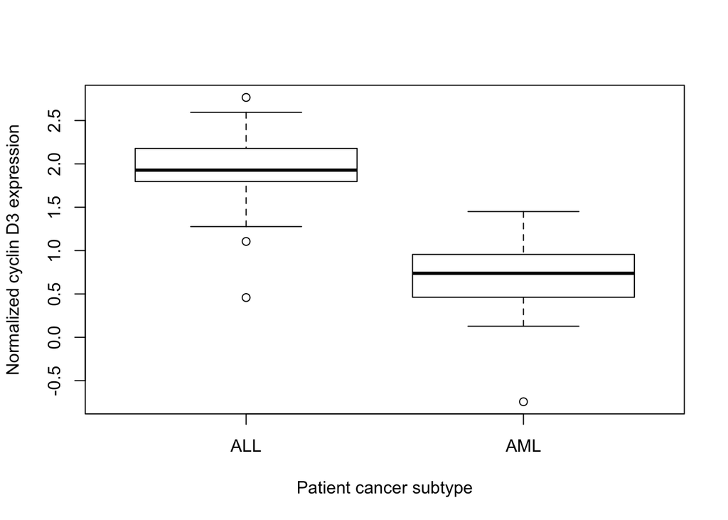

```r
boxplot(golub[1042,] ~ gol.fac, vertical=TRUE, xlab="Patient cancer subtype",  ylab="Normalized cyclin D3 expression", col=NULL)
```

4.8 b  
Box plots convey important figures of measurement such as median, quartiles, and outliers. Thus, if you wish to analyze distribution, the boxplot is your best bet. Strip charts also display distribution to a degree, but in return for less information than a boxplot, you preserve individual data points.

4.9

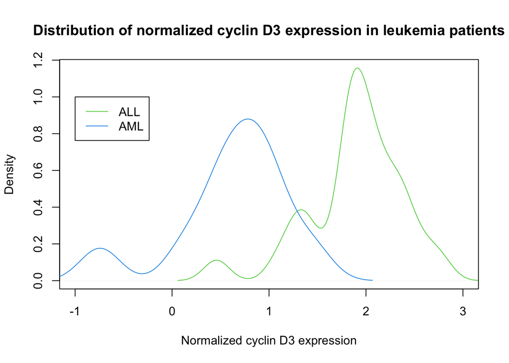

```r
plot(density(golub[1042,gol.fac=="ALL"]), col=3, xlim=range(-1, 3), xlab="Normalized cyclin D3 expression", main="Distribution of normalized cyclin D3 expression in leukemia patients")
lines(density(golub[1042,gol.fac=="AML"]), col=4)
legend(x=-1,y=1, legend=c("ALL","AML"), lty=1, col=c(3,4))
```

## Part 5: More advanced graphics in R

5.1

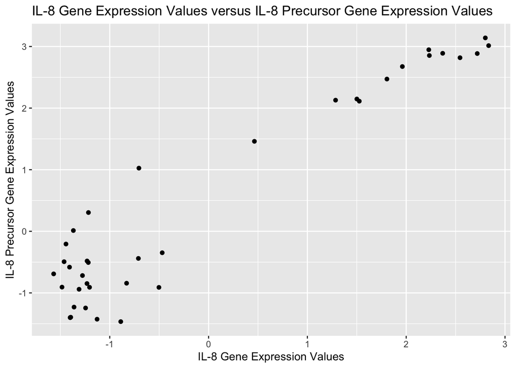

```r
library(ggplot2)
golub.data <- as.data.frame(t(golub))
ggplot(data = golub.data) + geom_point(aes(x = golub.data[,2663], y = golub.data[,2664])) + ggtitle("IL-8 Gene Expression Values versus IL-8 Precursor Gene Expression Values") + xlab("IL-8 Gene Expression Values") + ylab("IL-8 Precursor Gene Expression Values")
```

5.2

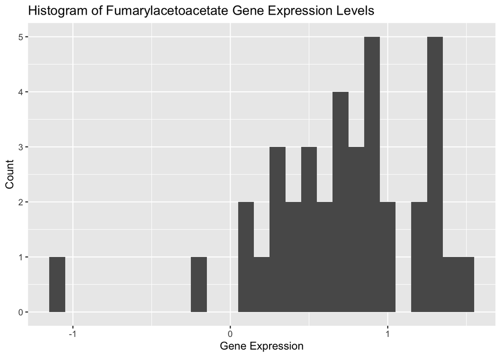

```r
pos <- grep("fumarylacetoacetate", golub.gnames[,2], ignore.case = TRUE)
ggplot(data = golub.data) + geom_histogram(aes(x = golub.data[,pos]), binwidth = 0.1) + ggtitle("Histogram of Fumarylacetoacetate Gene Expression Levels") + xlab("Gene Expression") + ylab("Count")
```

5.3

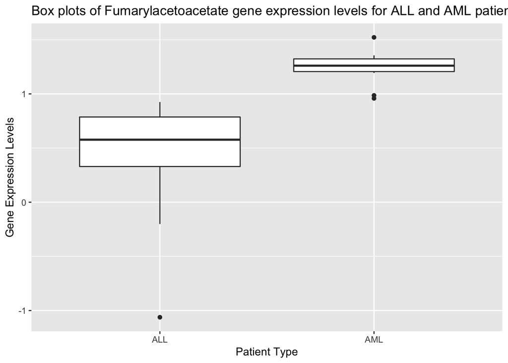

```r
ggplot(data = golub.data) + geom_boxplot(aes(x = gol.fac, y = golub.data[,pos])) + ggtitle("Box plots of Fumarylacetoacetate gene expression levels for ALL and AML patients") + xlab("Patient Type") + ylab("Gene Expression Levels")
```